# Esercitazione N.8

Regressione con Dati Panel

Autore/Autrice

Andrea Recine

Data di Pubblicazione

28 maggio 2026

# 1 Regressione con dati panel

Un panel contiene osservazioni su più unità (individui, stati, imprese) in cui ogni entità è osservata in due o più istanti temporali diversi:

Per esempio:

- Dati su 50 stati USA, ognuno è osservato per 3 anni, per un totale di 150 osservazioni.
- Dati su 1000 individui, in quattro mesi diversi, per 4000 osservazioni in totale.

Con i dati panel possiamo controllare per fattori che:

- Variano tra le unità ma non nel tempo (ad esempio variabili inosservate che variano da stato a stato, ma che non cambiano nel tempo)
- Variano nel tempo ma non tra le unità
- Potrebbero causare distorsione da variabili omesse
- Sono inosservati o non misurati, e perciò non possono essere inclusi in una regressione multipla

**Idea chiave:** Se una variabile omessa non varia nel tempo, allora qualsiasi variazione in $Y$ nel tempo non può essere causata dalla variabile omessa.

Questa è precisamente la logica degli **effetti fissi individuali**: assorbendo tutto ciò che è costante nel tempo per ciascuna unità, eliminano la distorsione dovuta a fattori *time-invariant* (osservati o no). Restano gli omessi che variano nel tempo. Ma se questi sono comuni a tutte le unità, possiamo controllare anche per quelli con **effetti fissi temporali**.

## 1.1 Setup

```r
library(tidyverse)
library(knitr)
library(kableExtra)
library(modelsummary)
library(fixest)
library(wooldridge)
```

# 2 Dataset `wagepan`

Unique

Missing Pct.

Mean

SD

Min

Median

Max

Histogram

nr

545

0

5262.1

3496.1

13.0

4569.0

12548.0

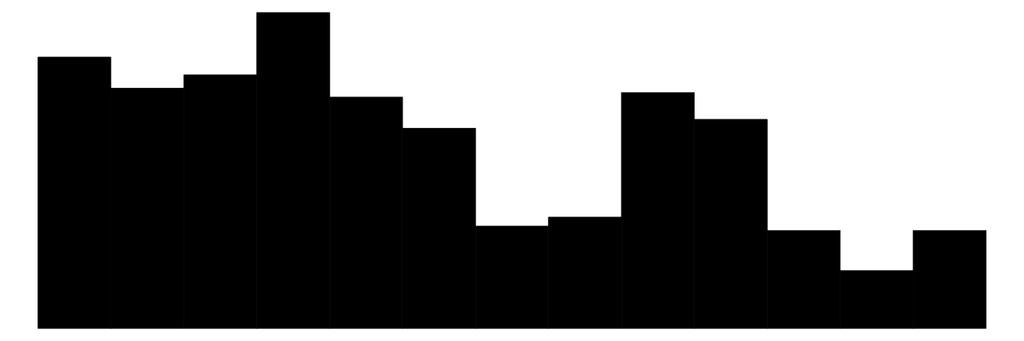

year

8

0

1983.5

2.3

1980.0

1983.5

1987.0

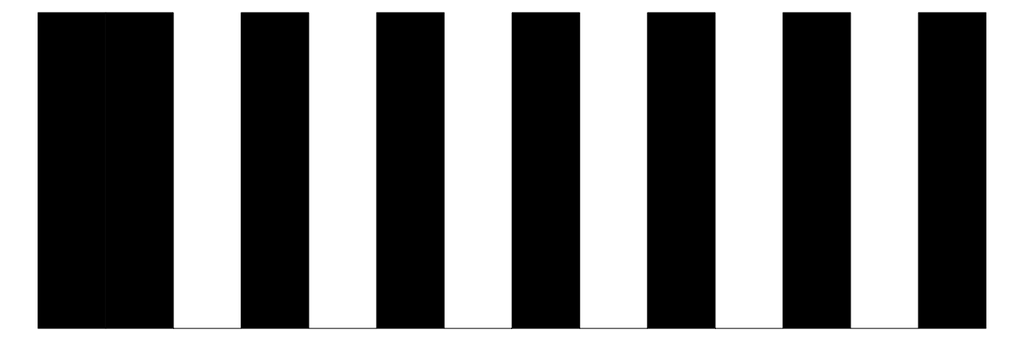

agric

2

0

0.0

0.2

0.0

0.0

1.0

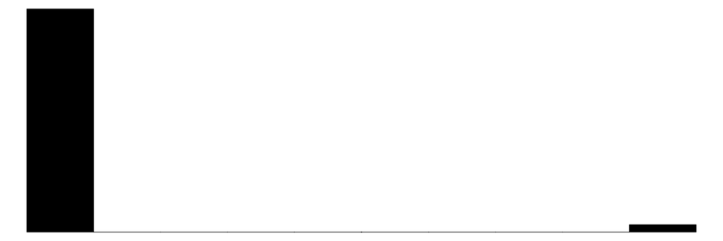

black

2

0

0.1

0.3

0.0

0.0

1.0

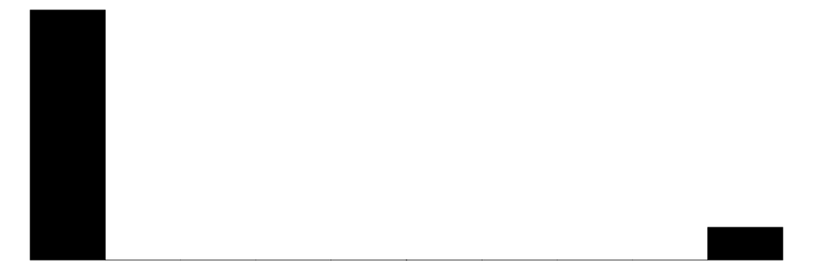

bus

2

0

0.1

0.3

0.0

0.0

1.0

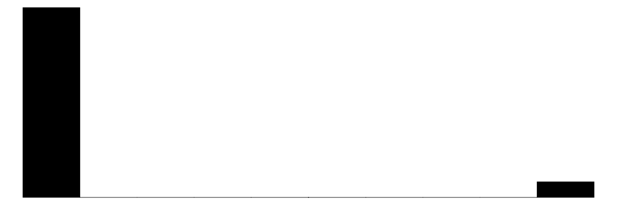

construc

2

0

0.1

0.3

0.0

0.0

1.0

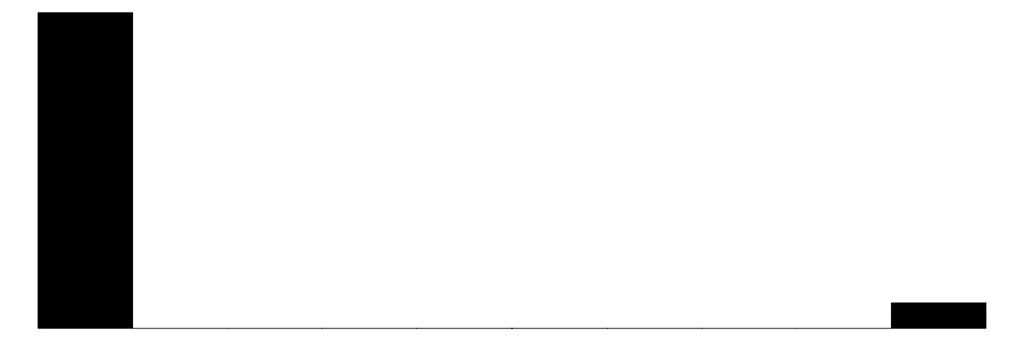

ent

2

0

0.0

0.1

0.0

0.0

1.0

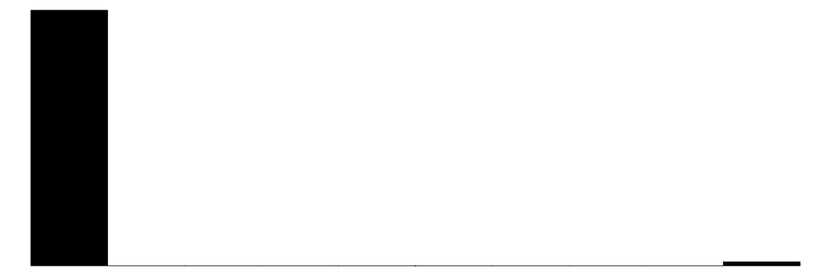

exper

19

0

6.5

2.8

0.0

6.0

18.0

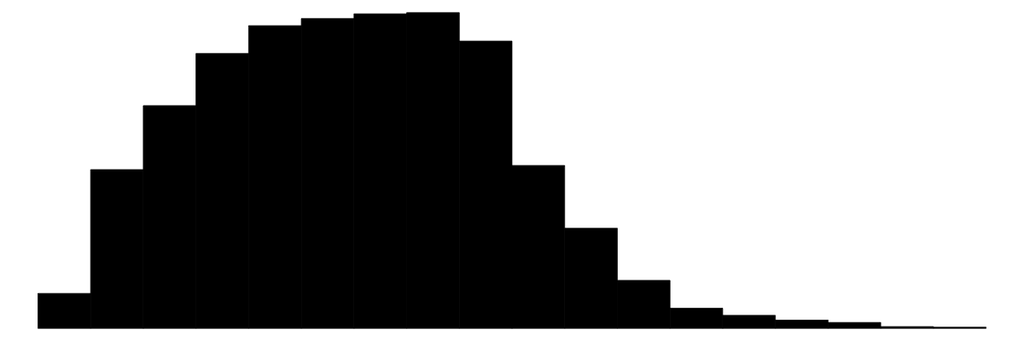

fin

2

0

0.0

0.2

0.0

0.0

1.0

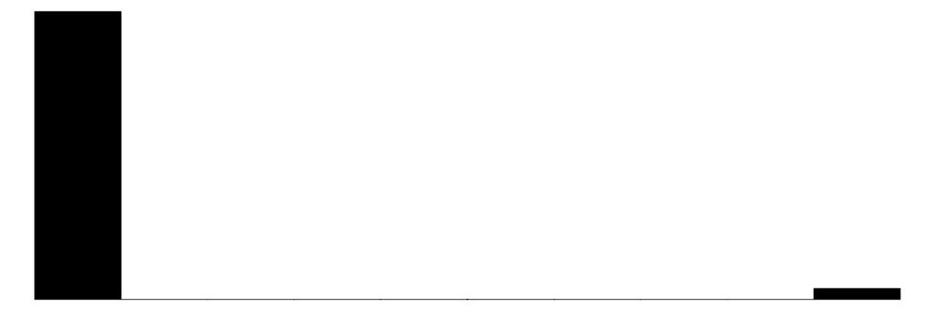

hisp

2

0

0.2

0.4

0.0

0.0

1.0

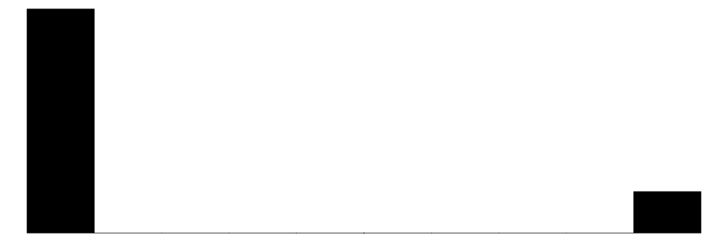

poorhlth

2

0

0.0

0.1

0.0

0.0

1.0

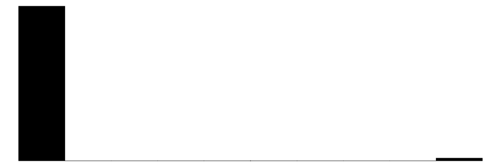

hours

1276

0

2191.3

566.4

120.0

2080.0

4992.0

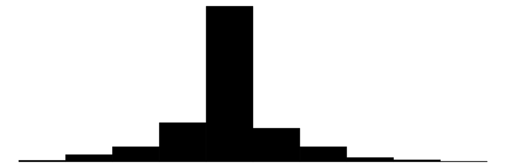

manuf

2

0

0.3

0.5

0.0

0.0

1.0

[25 more figures not shown]

```r
data("wagepan", package = "wooldridge")
datasummary_skim(wagepan)
```

Il dataset `wagepan` contiene dati sui salari di 545 lavoratori dal 1980 al 1987 (T=8).

In particolare usiamo:

- $lwage$: logaritmo del salario log(wage)
- $union$: variabile dummy uguale ad 1 se il lavoratore è sindacalizzato
- $exper$: anni di esperienza
- $expersq$: anni di esperienza al quadrato
- $educ$: anni di istruzione
- $black$: dummy uguale a 1 se il lavoratore è nero
- $hisp$: dummy uguale a 1 se il lavoratore è ispanico
- $married$: dummy uguale a 1 se il lavoratore è sposato

```r
head(wagepan)
```

```
#>   nr year agric black bus construc ent exper fin hisp poorhlth hours manuf
#> 1 13 1980     0     0   1        0   0     1   0    0        0  2672     0
#> 2 13 1981     0     0   0        0   0     2   0    0        0  2320     0
#> 3 13 1982     0     0   1        0   0     3   0    0        0  2940     0
#> 4 13 1983     0     0   1        0   0     4   0    0        0  2960     0
#> 5 13 1984     0     0   0        0   0     5   0    0        0  3071     0
#> 6 13 1985     0     0   1        0   0     6   0    0        0  2864     0
#>   married min nrthcen nrtheast occ1 occ2 occ3 occ4 occ5 occ6 occ7 occ8 occ9 per
#> 1       0   0       0        1    0    0    0    0    0    0    0    0    1   0
#> 2       0   0       0        1    0    0    0    0    0    0    0    0    1   1
#> 3       0   0       0        1    0    0    0    0    0    0    0    0    1   0
#> 4       0   0       0        1    0    0    0    0    0    0    0    0    1   0
#> 5       0   0       0        1    0    0    0    0    1    0    0    0    0   1
#> 6       0   0       0        1    0    1    0    0    0    0    0    0    0   0
#>   pro pub rur south educ tra trad union    lwage d81 d82 d83 d84 d85 d86 d87
#> 1   0   0   0     0   14   0    0     0 1.197540   0   0   0   0   0   0   0
#> 2   0   0   0     0   14   0    0     1 1.853060   1   0   0   0   0   0   0
#> 3   0   0   0     0   14   0    0     0 1.344462   0   1   0   0   0   0   0
#> 4   0   0   0     0   14   0    0     0 1.433213   0   0   1   0   0   0   0
#> 5   0   0   0     0   14   0    0     0 1.568125   0   0   0   1   0   0   0
#> 6   0   0   0     0   14   0    0     0 1.699891   0   0   0   0   1   0   0
#>   expersq
#> 1       1
#> 2       4
#> 3       9
#> 4      16
#> 5      25
#> 6      36
```

## 2.1 Pooled OLS

Come punto di partenza, stimiamo un modello che ignora la struttura panel.

```r
reg_pooled <- feols(lwage ~ union + exper + expersq + educ + black + hisp + married,
                    data = wagepan, vcov = "hetero")
reg_pooled
```

```
#> OLS estimation, Dep. Var.: lwage
#> Observations: 4,360
#> Standard-errors: Heteroskedasticity-robust
#>              Estimate Std. Error   t value   Pr(>|t|)
#> (Intercept) -0.034706   0.064745 -0.536039 5.9196e-01
#> union        0.180073   0.016242 11.086590  < 2.2e-16 ***
#> exper        0.089179   0.010148  8.788091  < 2.2e-16 ***
#> expersq     -0.002849   0.000679 -4.193440 2.8022e-05 ***
#> educ         0.099388   0.004596 21.626040  < 2.2e-16 ***
#> black       -0.143842   0.024361 -5.904497 3.8066e-09 ***
#> hisp         0.015698   0.019741  0.795178 4.2655e-01
#> married      0.107666   0.015266  7.052498 2.0350e-12 ***
#> ---
#> Signif. codes:  0 '***' 0.001 '**' 0.01 '*' 0.05 '.' 0.1 ' ' 1
#> RMSE: 0.480302   Adj. R2: 0.185278
```

**NotaDomande**

1. Come si interpretano i coefficienti di $educ$ e $union$ nella regressione?
- Essere sindacalizzato è **associato** a un salario medio più alto del 18% circa, a parità delle altre variabili.
- Ogni anno aggiuntivo di istruzione è **associato** a un salario medio più alto di circa 9.9%, a parità delle altre variabili.

# 3 T=2: Effetti fissi individuali

Iniziamo dal caso più semplice: due soli periodi di osservazione (1980 e 1987). Costruiamo un sottocampione con queste due annate.

```r
wagepan_2periods <- wagepan %>% filter(year %in% c(1980, 1987))
head(wagepan_2periods)
```

```
#>   nr year agric black bus construc ent exper fin hisp poorhlth hours manuf
#> 1 13 1980     0     0   1        0   0     1   0    0        0  2672     0
#> 2 13 1987     0     0   1        0   0     8   0    0        0  2640     0
#> 3 17 1980     0     0   0        0   0     4   0    0        0  2484     0
#> 4 17 1987     0     0   0        1   0    11   0    0        0  2476     0
#> 5 18 1980     0     0   0        0   0     4   0    0        0  2332     0
#> 6 18 1987     0     0   0        0   0    11   0    0        0  2340     0
#>   married min nrthcen nrtheast occ1 occ2 occ3 occ4 occ5 occ6 occ7 occ8 occ9 per
#> 1       0   0       0        1    0    0    0    0    0    0    0    0    1   0
#> 2       0   0       0        1    0    1    0    0    0    0    0    0    0   0
#> 3       0   0       0        1    0    1    0    0    0    0    0    0    0   0
#> 4       0   0       0        1    0    0    0    0    1    0    0    0    0   0
#> 5       1   0       0        0    0    0    0    1    0    0    0    0    0   0
#> 6       1   0       0        0    0    0    1    0    0    0    0    0    0   0
#>   pro pub rur south educ tra trad union    lwage d81 d82 d83 d84 d85 d86 d87
#> 1   0   0   0     0   14   0    0     0 1.197540   0   0   0   0   0   0   0
#> 2   0   0   0     0   14   0    0     0 1.669188   0   0   0   0   0   0   1
#> 3   0   0   0     0   13   0    1     0 1.675962   0   0   0   0   0   0   0
#> 4   0   0   0     0   13   0    0     0 1.820334   0   0   0   0   0   0   1
#> 5   0   0   0     0   12   0    1     0 1.515963   0   0   0   0   0   0   0
#> 6   0   0   0     0   12   0    1     0 2.873161   0   0   0   0   0   0   1
#>   expersq
#> 1       1
#> 2      64
#> 3      16
#> 4     121
#> 5      16
#> 6     121
```

Vogliamo stimare l’effetto di $union$ su $lwage$ (log(wage)) controllando per **effetti fissi individuali**, cioè caratteristiche del lavoratore che non variano nel tempo. Con T=2 esistono **tre modi equivalenti**:

1. First difference (senza intercetta)
2. Within transformation (deviazione dalla media individuale)
3. Dummy individuali

`library(fixest)` con il comando `feols(... | nr, ...)` implementa la trasformazione within in modo efficiente e correggendo gli errori standard [(Bergé et al. 2026)](https://arxiv.org/pdf/2601.21749)

## 3.1 First difference (senza intercetta)

Calcoliamo le differenze prime $\Delta y_i = y_{i,1987} - y_{i,1980}$ raggruppando per individuo (`group_by(nr)`) e ordinando per anno.

```r
wagepan_2periods_fd <- wagepan_2periods %>%
  arrange(nr, year) %>%
  group_by(nr) %>%
  mutate(
    d_lwage   = lwage   - lag(lwage),
    d_union   = union   - lag(union),
    d_exper   = exper   - lag(exper),
    d_expersq = expersq - lag(expersq),
    d_educ    = educ    - lag(educ),
    d_black   = black   - lag(black),
    d_hisp    = hisp    - lag(hisp),
    d_married = married - lag(married)
  ) %>%
  ungroup() %>%
  filter(!is.na(d_lwage))   # rimuove la riga 1980 di ogni individuo
```

Stimiamo la regressione **senza intercetta** (con `-1`):

```r
reg_fd <- feols(d_lwage ~ -1 + d_union + d_exper + d_expersq + d_educ + d_black + d_hisp + d_married,
                data = wagepan_2periods_fd, vcov = "hetero")
reg_fd
```

```
#> OLS estimation, Dep. Var.: d_lwage
#> Observations: 545
#> Standard-errors: Heteroskedasticity-robust
#>            Estimate Std. Error   t value   Pr(>|t|)
#> d_union    0.077484   0.054669  1.417329 1.5696e-01
#> d_exper    0.142162   0.014537  9.779206  < 2.2e-16 ***
#> d_expersq -0.005789   0.000972 -5.957972 4.6044e-09 ***
#> d_married  0.011707   0.042835  0.273292 7.8473e-01
#> ... 3 variables were removed because of collinearity (d_educ, d_black
#> and d_hisp)
#> ---
#> Signif. codes:  0 '***' 0.001 '**' 0.01 '*' 0.05 '.' 0.1 ' ' 1
#> RMSE: 0.588411   Adj. R2: 0.049078
```

Le variabili $educ$, $black$, $hisp$ sono costanti nel tempo per ogni individuo: la loro differenza prima è zero e vengono rimosse per collinearità. Questo è esattamente il senso degli effetti fissi individuali: assorbono tutto ciò che non varia nel tempo.

## 3.2 Within (deviazione dalla media individuale)

In alternativa, sottraiamo la media individuale a ciascuna variabile (`group_by(nr)`):

```r
wagepan_2periods_dm <- wagepan_2periods %>%
  group_by(nr) %>%
  mutate(
    lwage_dm   = lwage   - mean(lwage,   na.rm = TRUE),
    union_dm   = union   - mean(union,   na.rm = TRUE),
    exper_dm   = exper   - mean(exper,   na.rm = TRUE),
    expersq_dm = expersq - mean(expersq, na.rm = TRUE),
    educ_dm    = educ    - mean(educ,    na.rm = TRUE),
    black_dm   = black   - mean(black,   na.rm = TRUE),
    hisp_dm    = hisp    - mean(hisp,    na.rm = TRUE),
    married_dm = married - mean(married, na.rm = TRUE)
  ) %>%
  ungroup()
```

```r
reg_within <- feols(lwage_dm ~ union_dm + exper_dm + expersq_dm + educ_dm + black_dm + hisp_dm + married_dm,
                    data = wagepan_2periods_dm, vcov = "hetero")
reg_within
```

```
#> OLS estimation, Dep. Var.: lwage_dm
#> Observations: 1,090
#> Standard-errors: Heteroskedasticity-robust
#>                 Estimate Std. Error    t value  Pr(>|t|)
#> (Intercept)  0.000000000   0.008932  0.0000000  1.000000
#> union_dm     0.077483912   0.038603  2.0071829  0.044978 *
#> exper_dm     0.142162281   0.010265 13.8490455 < 2.2e-16 ***
#> expersq_dm  -0.005789266   0.000686 -8.4375181 < 2.2e-16 ***
#> married_dm   0.011706503   0.030247  0.3870284  0.698811
#> ... 3 variables were removed because of collinearity (educ_dm, black_dm
#> and hisp_dm)
#> ---
#> Signif. codes:  0 '***' 0.001 '**' 0.01 '*' 0.05 '.' 0.1 ' ' 1
#> RMSE: 0.294205   Adj. R2: 0.411529
```

L’intercetta è zero perché le variabili centrate hanno media nulla. Potremmo per completezza aggiungere `-1` nel comando di `feols`.

## 3.3 Dummy individuali

Possiamo anche includere esplicitamente una dummy per ciascun individuo con `as.factor(nr)`.

```r
reg_lsdv <- feols(lwage ~ as.factor(nr) + union + exper + expersq + educ + black + hisp + married,
                  data = wagepan_2periods, vcov = "hetero")
reg_lsdv
```

```
#> OLS estimation, Dep. Var.: lwage
#> Observations: 1,090
#> Standard-errors: Heteroskedasticity-robust
#>                   Estimate Std. Error   t value   Pr(>|t|)
#> (Intercept)       0.981785   0.087739 11.189879  < 2.2e-16 ***
#> as.factor(nr)17   0.096711   0.146397  0.660606 5.0915e-01
#> as.factor(nr)18   0.531418   0.494514  1.074627 2.8302e-01
#> as.factor(nr)45   0.452673   0.148847  3.041189 2.4706e-03 **
#> as.factor(nr)110  0.285018   0.093994  3.032311 2.5432e-03 **
#> as.factor(nr)120 -0.314296   0.677304 -0.464040 6.4281e-01
#> as.factor(nr)126  0.552497   0.100538  5.495386 6.0122e-08 ***
#> as.factor(nr)150 -0.536278   0.510896 -1.049682 2.9433e-01
#> ... 541 coefficients remaining (display them with summary() or use
#> argument n)
#> ... 3 variables were removed because of collinearity (educ, black and
#> hisp)
#> ---
#> Signif. codes:  0 '***' 0.001 '**' 0.01 '*' 0.05 '.' 0.1 ' ' 1
#> RMSE: 0.294205   Adj. R2: 0.455255
```

`feols` stima così **una dummy per ciascun individuo** (545 individui: l’intercetta più 544 dummy). Le variabili costanti nel tempo $educ$, $black$, $hisp$ vengono rimosse per collinearità.

L’output completo conterrebbe centinaia di righe: mostriamo solo le variabili di interesse con `keep`.

```r
etable(reg_lsdv, keep = c("union", "exper", "expersq"), order = c("union", "exper", "expersq"), signif.code = NA)
```

```
#>                         reg_lsdv
#> Dependent Var.:            lwage
#>
#> union            0.0775 (0.0547)
#> expersq         -0.0058 (0.0010)
#> exper            0.1422 (0.0145)
#> _______________ ________________
#> S.E. type       Heterosked.-rob.
#> Observations               1,090
#> R2                       0.72938
#> Adj. R2                  0.45525
```

Il coefficiente di $union$ è identico a quello ottenuto con first difference e within transformation.

## 3.4 `feols(... | nr, ...)`

Il pacchetto `fixest` con la sintassi `| nr` dove `nr` indica la dimensione degli effetti fissi:

```r
reg_fe_ind <- feols(lwage ~ union + exper + expersq + educ + black + hisp + married | nr,
                    data = wagepan_2periods, vcov = "hetero")
reg_fe_ind
```

```
#> OLS estimation, Dep. Var.: lwage
#> Observations: 1,090
#> Fixed-effects: nr: 545
#> Standard-errors: Heteroskedasticity-robust
#>          Estimate Std. Error   t value   Pr(>|t|)
#> union    0.077484   0.054669  1.417329 1.5696e-01
#> exper    0.142162   0.014537  9.779206  < 2.2e-16 ***
#> expersq -0.005789   0.000972 -5.957972 4.6044e-09 ***
#> married  0.011707   0.042835  0.273292 7.8473e-01
#> ... 3 variables were removed because of collinearity (educ, black and
#> hisp)
#> ---
#> Signif. codes:  0 '***' 0.001 '**' 0.01 '*' 0.05 '.' 0.1 ' ' 1
#> RMSE: 0.294205     Adj. R2: 0.455255
#>                  Within R2: 0.413691
```

**ImportanteEquivalenza con T=2**

Con T=2 i tre approcci sono **algebricamente equivalenti**: producono lo stesso coefficiente di $union$ (≈ 0.077). La trasformazione within fatta manualmente richiederebbe un aggiustamento degli errori standard, mentre `feols(... | nr, ...)` lo fa automaticamente. Con T>2 la trasformazione within e le dummy continuano a coincidere, ma la first difference no.

# 4 T=2: Effetti fissi individuali + temporali

Sempre nel sottocampione con T=2, aggiungiamo ora anche gli effetti fissi temporali. Controlliamo quindi congiuntamente per:

- caratteristiche individuali che non variano nel tempo (effetti fissi individuali);
- variazioni comuni a tutti gli individui che variano nel tempo (effetti fissi temporali).

## 4.1 First difference con intercetta

Stock & Watson (p. 283) mostrano che, quando T=2, includere un’**intercetta** nella regressione in differenze prime equivale a includere effetti fissi individuali **e** temporali. L’intercetta cattura la variazione media comune tra il 1980 e il 1987.

```r
reg_fd_int <- feols(d_lwage ~ d_union + d_exper + d_expersq + d_educ + d_black + d_hisp + d_married,
                    data = wagepan_2periods_fd, vcov = "hetero")
reg_fd_int
```

```
#> OLS estimation, Dep. Var.: d_lwage
#> Observations: 545
#> Standard-errors: Heteroskedasticity-robust
#>              Estimate Std. Error   t value   Pr(>|t|)
#> (Intercept)  0.995136   0.101760  9.779206  < 2.2e-16 ***
#> d_union      0.077484   0.054669  1.417329 1.5696e-01
#> d_expersq   -0.005789   0.000972 -5.957972 4.6044e-09 ***
#> d_married    0.011707   0.042835  0.273292 7.8473e-01
#> ... 4 variables were removed because of collinearity (d_exper, d_educ
#> and 2 others [full set in $collin.var])
#> ---
#> Signif. codes:  0 '***' 0.001 '**' 0.01 '*' 0.05 '.' 0.1 ' ' 1
#> RMSE: 0.588411   Adj. R2: 0.050823
```

`d_exper` viene rimossa per collinearità: tra 1980 e 1987 ogni individuo ha guadagnato esattamente 7 anni di esperienza, quindi $\Delta exper$ è una costante perfettamente collineare con l’intercetta.

## 4.2 `feols(... | nr + year, ...)`

```r
reg_fe_indtime <- feols(lwage ~ union + exper + expersq + educ + black + hisp + married | nr + year,
                        data = wagepan_2periods, vcov = "hetero")
reg_fe_indtime
```

```
#> OLS estimation, Dep. Var.: lwage
#> Observations: 1,090
#> Fixed-effects: nr: 545,  year: 2
#> Standard-errors: Heteroskedasticity-robust
#>          Estimate Std. Error   t value   Pr(>|t|)
#> union    0.077484   0.054669  1.417329 1.5696e-01
#> expersq -0.005789   0.000972 -5.957972 4.6044e-09 ***
#> married  0.011707   0.042835  0.273292 7.8473e-01
#> ... 4 variables were removed because of collinearity (exper, educ and 2
#> others [full set in $collin.var])
#> ---
#> Signif. codes:  0 '***' 0.001 '**' 0.01 '*' 0.05 '.' 0.1 ' ' 1
#> RMSE: 0.294205     Adj. R2: 0.455255
#>                  Within R2: 0.056058
```

Vedremo nel prossimo capitolo che con T>2 questa coincidenza scompare.

# 5 T>2: Panel completo

Torniamo ora al panel completo (T=8, 545 individui, 4360 osservazioni).

## 5.1 Within (deviazione dalla media individuale)

```r
wagepan_dm <- wagepan %>%
  group_by(nr) %>%
  mutate(
    lwage_dm   = lwage   - mean(lwage,   na.rm = TRUE),
    union_dm   = union   - mean(union,   na.rm = TRUE),
    exper_dm   = exper   - mean(exper,   na.rm = TRUE),
    expersq_dm = expersq - mean(expersq, na.rm = TRUE),
    educ_dm    = educ    - mean(educ,    na.rm = TRUE),
    black_dm   = black   - mean(black,   na.rm = TRUE),
    hisp_dm    = hisp    - mean(hisp,    na.rm = TRUE),
    married_dm = married - mean(married, na.rm = TRUE)
  ) %>%
  ungroup()

reg_within_full <- feols(lwage_dm ~ -1 + union_dm + exper_dm + expersq_dm + educ_dm + black_dm + hisp_dm + married_dm,
                         data = wagepan_dm, vcov = "hetero")
reg_within_full
```

```
#> OLS estimation, Dep. Var.: lwage_dm
#> Observations: 4,360
#> Standard-errors: Heteroskedasticity-robust
#>             Estimate Std. Error  t value   Pr(>|t|)
#> union_dm    0.082087   0.018235  4.50155 6.9222e-06 ***
#> exper_dm    0.116847   0.008546 13.67335  < 2.2e-16 ***
#> expersq_dm -0.004301   0.000560 -7.67822 1.9790e-14 ***
#> married_dm  0.045303   0.016954  2.67211 7.5657e-03 **
#> ... 3 variables were removed because of collinearity (educ_dm, black_dm
#> and hisp_dm)
#> ---
#> Signif. codes:  0 '***' 0.001 '**' 0.01 '*' 0.05 '.' 0.1 ' ' 1
#> RMSE: 0.328397   Adj. R2: 0.177289
```

## 5.2 `feols(... | nr, ...)`

```r
reg_fe_ind_full <- feols(lwage ~ union + exper + expersq + educ + black + hisp + married | nr,
                         data = wagepan, vcov = "hetero")
reg_fe_ind_full
```

```
#> OLS estimation, Dep. Var.: lwage
#> Observations: 4,360
#> Fixed-effects: nr: 545
#> Standard-errors: Heteroskedasticity-robust
#>          Estimate Std. Error  t value   Pr(>|t|)
#> union    0.082087   0.019496  4.21054 2.6065e-05 ***
#> exper    0.116847   0.009136 12.78941  < 2.2e-16 ***
#> expersq -0.004301   0.000599 -7.18184 8.2311e-13 ***
#> married  0.045303   0.018126  2.49936 1.2483e-02 *
#> ... 3 variables were removed because of collinearity (educ, black and
#> hisp)
#> ---
#> Signif. codes:  0 '***' 0.001 '**' 0.01 '*' 0.05 '.' 0.1 ' ' 1
#> RMSE: 0.328397     Adj. R2: 0.565061
#>                  Within R2: 0.178044
```

Le variabili $educ$, $black$, $hisp$ sono costanti a livello individuale e quindi collineari con gli effetti fissi: vengono rimosse.

## 5.3 First difference sul panel completo

```r
wagepan_fd <- wagepan %>%
  arrange(nr, year) %>%
  group_by(nr) %>%
  mutate(
    d_lwage   = lwage   - lag(lwage),
    d_union   = union   - lag(union),
    d_exper   = exper   - lag(exper),
    d_expersq = expersq - lag(expersq),
    d_educ    = educ    - lag(educ),
    d_black   = black   - lag(black),
    d_hisp    = hisp    - lag(hisp),
    d_married = married - lag(married)
  ) %>%
  ungroup() %>%
  filter(!is.na(d_lwage))

reg_fd_full <- feols(d_lwage ~ -1 + d_union + d_exper + d_expersq + d_educ + d_black + d_hisp + d_married,
                     data = wagepan_fd, vcov = "hetero")
reg_fd_full
```

```
#> OLS estimation, Dep. Var.: d_lwage
#> Observations: 3,815
#> Standard-errors: Heteroskedasticity-robust
#>            Estimate Std. Error  t value   Pr(>|t|)
#> d_union    0.042788   0.019822  2.15862 3.0942e-02 *
#> d_exper    0.115750   0.021142  5.47499 4.6575e-08 ***
#> d_expersq -0.003882   0.001389 -2.79496 5.2166e-03 **
#> d_married  0.038138   0.023285  1.63784 1.0154e-01
#> ... 3 variables were removed because of collinearity (d_educ, d_black
#> and d_hisp)
#> ---
#> Signif. codes:  0 '***' 0.001 '**' 0.01 '*' 0.05 '.' 0.1 ' ' 1
#> RMSE: 0.442807   Adj. R2: 0.003158
```

**ImportanteCon T>2 la first difference si sgancia**

La **first difference** dà un coefficiente diverso (≈ 0.043): entrambi gli stimatori restano consistenti sotto le ipotesi standard, ma usano l’informazione del panel in modo diverso.

## 5.4 Effetti fissi individuali e temporali

```r
reg_fe_indtime_full <- feols(lwage ~ union + exper + expersq + educ + black + hisp + married | nr + year,
                             data = wagepan, vcov = "hetero")
reg_fe_indtime_full
```

```
#> OLS estimation, Dep. Var.: lwage
#> Observations: 4,360
#> Fixed-effects: nr: 545,  year: 8
#> Standard-errors: Heteroskedasticity-robust
#>          Estimate Std. Error  t value   Pr(>|t|)
#> union    0.080002   0.019505  4.10154 4.1899e-05 ***
#> expersq -0.005185   0.000665 -7.80118 7.8642e-15 ***
#> married  0.046680   0.018117  2.57658 1.0016e-02 *
#> ... 4 variables were removed because of collinearity (exper, educ and 2
#> others [full set in $collin.var])
#> ---
#> Signif. codes:  0 '***' 0.001 '**' 0.01 '*' 0.05 '.' 0.1 ' ' 1
#> RMSE: 0.327891     Adj. R2: 0.565718
#>                  Within R2: 0.021568
```

Come vedete, 4 variabili vengono rimosse ($exper$, $educ$, $black$, $hisp$): $exper$ è collineare con gli effetti fissi temporali (cresce di 1 ogni anno per ciascun individuo), le altre tre sono collineari con gli effetti fissi individuali.

**Confronto finale su wagepan:**

```r
modelsummary(
  list("Pooled OLS"   = reg_pooled,
       "FE | nr"      = reg_fe_ind_full,
       "FE | nr+year" = reg_fe_indtime_full),
  gof_omit = "AIC|BIC|RMSE|R2 Adj."
)
```

|  | Pooled OLS | FE \| nr | FE \| nr+year |
| --- | --- | --- | --- |
| (Intercept) | -0.035 |  |  |
|  | (0.065) |  |  |
| union | 0.180 | 0.082 | 0.080 |
|  | (0.016) | (0.019) | (0.020) |
| exper | 0.089 | 0.117 |  |
|  | (0.010) | (0.009) |  |
| expersq | -0.003 | -0.004 | -0.005 |
|  | (0.001) | (0.001) | (0.001) |
| educ | 0.099 |  |  |
|  | (0.005) |  |  |
| black | -0.144 |  |  |
|  | (0.024) |  |  |
| hisp | 0.016 |  |  |
|  | (0.020) |  |  |
| married | 0.108 | 0.045 | 0.047 |
|  | (0.015) | (0.018) | (0.018) |
| Num.Obs. | 4360 | 4360 | 4360 |
| R2 | 0.187 | 0.620 | 0.621 |
| R2 Within |  | 0.178 | 0.022 |
| R2 Within Adj. |  | 0.177 | 0.021 |
| FE: nr |  | X | X |
| FE: year |  |  | X |

Il coefficiente di $union$ scende da 0.18 (cioè 18%) a 0.08 (circa 8% con effetti fissi individuali + temporali): metà dell’associazione iniziale era riconducibile a caratteristiche individuali e a shock temporali correlati con la sindacalizzazione.

# 6 Errori standard clustered

Finora abbiamo usato errori standard robusti all’eteroschedasticità (Eicker-Huber-White). Con i dati sezionali sono adeguati: ogni osservazione è un’unità indipendente, e l’unico problema da correggere è che la varianza degli errori non sia costante. Questi errori standard **lasciano variare** la varianza $\text{Var}(u_i)$ da osservazione a osservazione, ma **assumono** che gli errori di osservazioni diverse siano incorrelati, $\text{Cov}(u_i, u_j) = 0$ per $i \neq j$.

In un panel lo stesso individuo è osservato più volte, e i suoi errori nel tempo sono quasi sempre **correlati**: caratteristiche non osservate e shock persistenti (abilità, motivazione, condizioni locali). È la **correlazione seriale entro l’individuo**.

Gli errori standard *clustered* sono costruiti proprio per questo: consentono correlazione **arbitraria entro un cluster** — qui l’individuo (`nr`) — sia essa eteroschedasticità e/o correlazione seriale, ma assumono indipendenza **tra** cluster diversi. Sono quindi validi indipendentemente dalla presenza di eteroschedasticità e/o correlazione seriale entro l’individuo.

Se usassimo solo `vcov = "hetero"`, gli errori standard vengono **sottostimati**, le statistiche $t$ risultano troppo grandi e si tende a rifiutare l’ipotesi nulla troppo spesso (falsa significatività). In sostanza, la correlazione seriale degli errori all’interno di ciascun individuo rende inaffidabili gli errori standard robusti. Gli errori clustered correggono questa distorsione.

```r
reg_fe_cluster <- feols(lwage ~ union + exper + expersq + educ + black + hisp + married | nr + year,
                        data = wagepan, vcov = "cluster")
modelsummary(
  list("FE (hetero)"      = reg_fe_indtime_full,
       "FE (cluster, nr)" = reg_fe_cluster),
  gof_omit = "AIC|BIC|RMSE|R2 Adj."
)
```

|  | FE (hetero) | FE (cluster, nr) |
| --- | --- | --- |
| union | 0.080 | 0.080 |
|  | (0.020) | (0.023) |
| expersq | -0.005 | -0.005 |
|  | (0.001) | (0.001) |
| married | 0.047 | 0.047 |
|  | (0.018) | (0.021) |
| Num.Obs. | 4360 | 4360 |
| R2 | 0.621 | 0.621 |
| R2 Within | 0.022 | 0.022 |
| R2 Within Adj. | 0.021 | 0.021 |
| FE: nr | X | X |
| FE: year | X | X |

Se selezioniamo `vcov = "cluster"`, `feols` usa automaticamente la prima dimensione degli effetti fissi per identificare i cluster: qui `nr` (individui). Altrimenti possiamo usare `vcov = ~nr`.

# 7 Crimine e disoccupazione

Carichiamo il dataset `crime2` con osservazioni su 46 città USA, ognuna osservata nel 1982 e nel 1987 (T=2, $n \times T = 92$ osservazioni):

- $crmrte$: tasso di crimine ogni 1.000 abitanti
- $unem$: tasso di disoccupazione

```r
data("crime2", package = "wooldridge")
head(crime2)
```

```
#>      pop crimes unem officers pcinc west nrtheast south year  area d87   popden
#> 1 229528  17136  8.2      326  8532    1        0     0   82  44.6   0 5146.368
#> 2 246815  17306  3.7      321 12155    1        0     0   87  44.6   1 5533.969
#> 3 814054  75654  8.1     1621  7551    1        0     0   82 375.0   0 2170.811
#> 4 933177  83960  5.4     1803 11363    1        0     0   87 375.0   1 2488.472
#> 5 374974  31352  9.0      633  8343    1        0     0   82  49.8   0 7529.599
#> 6 406297  31364  5.9      685 11729    1        0     0   87  49.8   1 8158.574
#>     crmrte   offarea   lawexpc    polpc     lpop   loffic   lpcinc llawexpc
#> 1 74.65756  7.309417  850.8599 1.420306 12.34378 5.786897 9.051579 6.746247
#> 2 70.11729  7.197309 2262.4399 1.300569 12.41639 5.771441 9.405496 7.724199
#> 3 92.93487  4.322667  875.0800 1.991268 13.60978 7.390799 8.929436 6.774315
#> 4 89.97221  4.808000 1069.6400 1.932109 13.74635 7.497207 9.338118 6.975078
#> 5 83.61113 12.710844 1121.8999 1.688117 12.83461 6.450470 9.029179 7.022779
#> 6 77.19476 13.755020 1545.6000 1.685959 12.91484 6.529419 9.369820 7.343167
#>    lpopden   lcrimes    larea  lcrmrte     clcrimes      clpop    clcrmrte
#> 1 8.546046  9.748937 3.797734 4.312912           NA         NA          NA
#> 2 8.618661  9.758808 3.797734 4.250169 0.0098714828 0.07261372 -0.06274271
#> 3 7.682856 11.233926 5.926926 4.531899           NA         NA          NA
#> 4 7.819424 11.338096 5.926926 4.499501 0.1041698456 0.13656807 -0.03239822
#> 5 8.926597 10.353033 3.908015 4.426177           NA         NA          NA
#> 6 9.006824 10.353416 3.908015 4.346332 0.0003833771 0.08022785 -0.07984495
#>      lpolpc      clpolpc  cllawexp cunem   clpopden lcrmrt_1   ccrmrte
#> 1 0.3508723           NA        NA    NA         NA       NA        NA
#> 2 0.2628021 -0.088070214 0.9779520  -4.5 0.07261467 4.312912 -4.540268
#> 3 0.6887718           NA        NA    NA         NA       NA        NA
#> 4 0.6586123 -0.030159533 0.2007623  -2.7 0.13656807 4.531899 -2.962654
#> 5 0.5236138           NA        NA    NA         NA       NA        NA
#> 6 0.5223344 -0.001279354 0.3203883  -3.1 0.08022785 4.426177 -6.416374
```

`crime2` non contiene una colonna esplicita con l’identificativo della città: le righe sono ordinate in modo che ogni coppia consecutiva di osservazioni si riferisca alla stessa città (riga 1 = città 1, anno 1982; riga 2 = città 1, anno 1987; e così via). Creiamo a mano la variabile `city`:

```r
crime2 <- crime2 %>%
  mutate(city = rep(1:(nrow(crime2)/2), each = 2))
```

`ccrmrte` e `cunem` contengono già le differenze prime $1987 - 1982$ per ciascuna città (sono `NA` sulla riga 1982 e contengono il valore sulla riga 1987).

## 7.1 Pooled OLS

```r
regc_pooled <- feols(crmrte ~ unem, data = crime2, vcov = "hetero")
regc_pooled
```

```
#> OLS estimation, Dep. Var.: crmrte
#> Observations: 92
#> Standard-errors: Heteroskedasticity-robust
#>               Estimate Std. Error   t value  Pr(>|t|)
#> (Intercept) 103.243399   8.641502 11.947390 < 2.2e-16 ***
#> unem         -0.307664   0.910013 -0.338087   0.73608
#> ---
#> Signif. codes:  0 '***' 0.001 '**' 0.01 '*' 0.05 '.' 0.1 ' ' 1
#> RMSE: 29.7   Adj. R2: -0.009888
```

Un aumento di un punto percentuale del tasso di disoccupazione è **associato**, in media, a una riduzione di circa 0.31 crimini per 1.000 abitanti. Risultato controintuitivo: la relazione tra disoccupazione e crimine è confusa da caratteristiche delle città (densità, demografia, ricchezza) e da differenze tra i due anni.

## 7.2 Effetti fissi temporali

Possiamo controllare per shock comuni alle città in ogni anno (effetti fissi temporali) in tre modi equivalenti.

**Dummy esplicita `d87`:**

```r
regc_d87 <- feols(crmrte ~ unem + d87, data = crime2, vcov = "hetero")
regc_d87
```

```
#> OLS estimation, Dep. Var.: crmrte
#> Observations: 92
#> Standard-errors: Heteroskedasticity-robust
#>              Estimate Std. Error  t value   Pr(>|t|)
#> (Intercept) 93.420250  10.457957 8.932935 5.1717e-14 ***
#> unem         0.426547   0.993554 0.429315 6.6873e-01
#> d87          7.940416   7.106315 1.117375 2.6684e-01
#> ---
#> Signif. codes:  0 '***' 0.001 '**' 0.01 '*' 0.05 '.' 0.1 ' ' 1
#> RMSE: 29.5   Adj. R2: -0.009986
```

**`feols(... | year, ...)`:**

```r
regc_fe_year <- feols(crmrte ~ unem | year, data = crime2, vcov = "hetero")
regc_fe_year
```

```
#> OLS estimation, Dep. Var.: crmrte
#> Observations: 92
#> Fixed-effects: year: 2
#> Standard-errors: Heteroskedasticity-robust
#>      Estimate Std. Error  t value Pr(>|t|)
#> unem 0.426547   0.993554 0.429315  0.66873
#> ---
#> Signif. codes:  0 '***' 0.001 '**' 0.01 '*' 0.05 '.' 0.1 ' ' 1
#> RMSE: 29.5     Adj. R2: -0.009986
#>              Within R2:  0.001446
```

**Within per anno** (sottraiamo a ciascuna città la media calcolata sulle città osservate nello stesso anno):

```r
crime2_dm_year <- crime2 %>%
  group_by(year) %>%
  mutate(crmrte_dm = crmrte - mean(crmrte),
         unem_dm   = unem   - mean(unem)) %>%
  ungroup()

regc_within_year <- feols(crmrte_dm ~ -1 + unem_dm, data = crime2_dm_year, vcov = "hetero")
regc_within_year
```

```
#> OLS estimation, Dep. Var.: crmrte_dm
#> Observations: 92
#> Standard-errors: Heteroskedasticity-robust
#>         Estimate Std. Error  t value Pr(>|t|)
#> unem_dm 0.426547   0.982575 0.434112  0.66523
#> ---
#> Signif. codes:  0 '***' 0.001 '**' 0.01 '*' 0.05 '.' 0.1 ' ' 1
#> RMSE: 29.5   Adj. R2: -0.009527
```

```r
modelsummary(
  list("Dummy d87"    = regc_d87,
       "|year"        = regc_fe_year,
       "Within anno"  = regc_within_year),
  gof_omit = "AIC|BIC|RMSE|R2 Adj."
)
```

|  | Dummy d87 | \|year | Within anno |
| --- | --- | --- | --- |
| (Intercept) | 93.420 |  |  |
|  | (10.458) |  |  |
| unem | 0.427 | 0.427 |  |
|  | (0.994) | (0.994) |  |
| d87 | 7.940 |  |  |
|  | (7.106) |  |  |
| unem_dm |  |  | 0.427 |
|  |  |  | (0.983) |
| Num.Obs. | 92 | 92 | 92 |
| R2 | 0.012 | 0.012 | -0.010 |
| R2 Within |  | 0.001 |  |
| R2 Within Adj. |  | -0.010 |  |
| FE: year |  | X |  |

Una volta tolto l’effetto comune dell’anno, l’associazione tra disoccupazione e crimine cambia segno: $unem$ è ora associato a un aumento di circa 0.43 crimini per 1.000 abitanti.

## 7.3 Effetti fissi per città

**First difference (senza intercetta)** — usa direttamente `ccrmrte` e `cunem` già nel dataset:

```r
regc_fd <- feols(ccrmrte ~ -1 + cunem, data = crime2, vcov = "hetero")
regc_fd
```

```
#> OLS estimation, Dep. Var.: ccrmrte
#> Observations: 46
#> Standard-errors: Heteroskedasticity-robust
#>        Estimate Std. Error  t value Pr(>|t|)
#> cunem -0.018094   0.441965 -0.04094  0.96752
#> ---
#> Signif. codes:  0 '***' 0.001 '**' 0.01 '*' 0.05 '.' 0.1 ' ' 1
#> RMSE: 21.9   Adj. R2: -0.110395
```

**`feols(... | city, ...)`:**

```r
regc_fe_city <- feols(crmrte ~ unem | city, data = crime2, vcov = "hetero")
regc_fe_city
```

```
#> OLS estimation, Dep. Var.: crmrte
#> Observations: 92
#> Fixed-effects: city: 46
#> Standard-errors: Heteroskedasticity-robust
#>       Estimate Std. Error  t value Pr(>|t|)
#> unem -0.018094   0.441965 -0.04094  0.96752
#> ---
#> Signif. codes:  0 '***' 0.001 '**' 0.01 '*' 0.05 '.' 0.1 ' ' 1
#> RMSE: 10.9     Adj. R2: 0.725492
#>              Within R2: 1.964e-5
```

```r
modelsummary(
  list("FD (no intercetta)" = regc_fd,
       "|city"              = regc_fe_city),
  gof_omit = "AIC|BIC|RMSE|R2 Adj."
)
```

|  | FD (no intercetta) | \|city |
| --- | --- | --- |
| cunem | -0.018 |  |
|  | (0.442) |  |
| unem |  | -0.018 |
|  |  | (0.442) |
| Num.Obs. | 46 | 92 |
| R2 | -0.110 | 0.864 |
| R2 Within |  | 0.000 |
| R2 Within Adj. |  | -0.022 |
| FE: city |  | X |

## 7.4 Effetti fissi individuali + temporali

Applichiamo il risultato di Stock & Watson (p. 283): con T=2, la **first difference con intercetta** è equivalente a includere FE individuali e temporali.

```r
regc_fd_int <- feols(ccrmrte ~ cunem, data = crime2, vcov = "hetero")
regc_fd_int
```

```
#> OLS estimation, Dep. Var.: ccrmrte
#> Observations: 46
#> Standard-errors: Heteroskedasticity-robust
#>             Estimate Std. Error t value  Pr(>|t|)
#> (Intercept)  15.4022   5.178907 2.97403 0.0047563 **
#> cunem         2.2180   0.815506 2.71978 0.0093165 **
#> ---
#> Signif. codes:  0 '***' 0.001 '**' 0.01 '*' 0.05 '.' 0.1 ' ' 1
#> RMSE: 19.6   Adj. R2: 0.106852
```

```r
regc_fe_full <- feols(crmrte ~ unem | city + year, data = crime2, vcov = "hetero")
regc_fe_full
```

```
#> OLS estimation, Dep. Var.: crmrte
#> Observations: 92
#> Fixed-effects: city: 46,  year: 2
#> Standard-errors: Heteroskedasticity-robust
#>      Estimate Std. Error t value  Pr(>|t|)
#> unem    2.218   0.815506 2.71978 0.0093165 **
#> ---
#> Signif. codes:  0 '***' 0.001 '**' 0.01 '*' 0.05 '.' 0.1 ' ' 1
#> RMSE: 9.80504     Adj. R2: 0.774292
#>                 Within R2: 0.1267
```

```r
modelsummary(
  list("FD con intercetta"  = regc_fd_int,
       "|city + year"       = regc_fe_full),
  gof_omit = "AIC|BIC|RMSE|R2 Adj."
)
```

|  | FD con intercetta | \|city + year |
| --- | --- | --- |
| (Intercept) | 15.402 |  |
|  | (5.179) |  |
| cunem | 2.218 |  |
|  | (0.816) |  |
| unem |  | 2.218 |
|  |  | (0.816) |
| Num.Obs. | 46 | 92 |
| R2 | 0.127 | 0.891 |
| R2 Within |  | 0.127 |
| R2 Within Adj. |  | 0.107 |
| FE: city |  | X |
| FE: year |  | X |

Controllando sia per gli effetti fissi per unità sia per quelli temporali, un punto percentuale in più di disoccupazione è associato a un aumento di circa 2.2 crimini per 1.000 abitanti.